# Chapter 3 Linear Regression and Performance Measures

# 3.1 Simple linear regression & correlation

Linear regression is to find a straight line to fit the data, to see how a response depends on some predictors (independent variables). The goal of simple linear regression is to fit a straight line to the data that best represents the relationship between the response and the predictor ( a straight line to minimize the prediction error). In Simple linear regression, there is only one predictor.

In a simple linear regression, there is only one predictor. The mathematical model:

$$y_i = \beta_0 + \beta_1 x_i + e_i$$

where $\beta_0$ is the intercept, $\beta_1$ is the slope and $e_i$ is the error term.

In machine learning workflows, simple linear regression is usually as the first supervised model for regression tasks, valued more for its interpretability and clarity than for raw predictive power.

Example: Use R dataset "cars". Speed : driving speed. dist: the distance to stop. Construct a predictive model (a simple linear regression) to predict stoping distance based on the driving speed.

```
  Response:   dist

  Predictor:  speed
```

```r
# R codes
data(cars)
head(cars)
#head(cars)
```

A data.frame: 6 × 2

|  | speed <dbl> | dist <dbl> |
| --- | --- | --- |
| 1 | 4 | 2 |
| 2 | 4 | 10 |
| 3 | 7 | 4 |
| 4 | 7 | 22 |
| 5 | 8 | 16 |
| 6 | 9 | 10 |

```r
#Run a simple linear regression, lm: linear models
#fit = lm( cars$dist ~  cars$speed)
fit = lm( dist ~  speed, data = cars)
summary(fit)

#The fitted model
```

```
Call:
lm(formula = dist ~ speed, data = cars)

Residuals:
    Min      1Q  Median      3Q     Max
-29.069  -9.525  -2.272   9.215  43.201

Coefficients:
            Estimate Std. Error t value Pr(>|t|)
(Intercept) -17.5791     6.7584  -2.601   0.0123 *
speed         3.9324     0.4155   9.464 1.49e-12 ***
---
Signif. codes:  0 ‘***’ 0.001 ‘**’ 0.01 ‘*’ 0.05 ‘.’ 0.1 ‘ ’ 1

Residual standard error: 15.38 on 48 degrees of freedom
Multiple R-squared:  0.6511,	Adjusted R-squared:  0.6438
F-statistic: 89.57 on 1 and 48 DF,  p-value: 1.49e-12
```

The predictive (fitted) model: $ \hat{dist} = -17.57 + 3.93 speed $

When the speed is zero, the stopping distance is zero.

Another model: $$y_i = \beta_1 x_i + e_i$$

```r
#Run a simple linear regression with intercept
fit2 = lm( dist ~ -1 + speed, data = cars)
summary(fit2)
```

```
Call:
lm(formula = dist ~ -1 + speed, data = cars)

Residuals:
    Min      1Q  Median      3Q     Max
-26.183 -12.637  -5.455   4.590  50.181

Coefficients:
      Estimate Std. Error t value Pr(>|t|)
speed   2.9091     0.1414   20.58   <2e-16 ***
---
Signif. codes:  0 ‘***’ 0.001 ‘**’ 0.01 ‘*’ 0.05 ‘.’ 0.1 ‘ ’ 1

Residual standard error: 16.26 on 49 degrees of freedom
Multiple R-squared:  0.8963,	Adjusted R-squared:  0.8942
F-statistic: 423.5 on 1 and 49 DF,  p-value: < 2.2e-16
```

The preditive model: $ \hat{dist} = 2.909 Speed $

The p-value of "speed" is <2e-16 (0.000). If the p-value is below (=) the level of signficance 0.05, there is sufficient evidence in the data to support that the slope of speed is not zero. The speed is usful to predict the stopping distance.

Is the prediction perfect or not?  
According to the plots below, the prediction is not perfect.

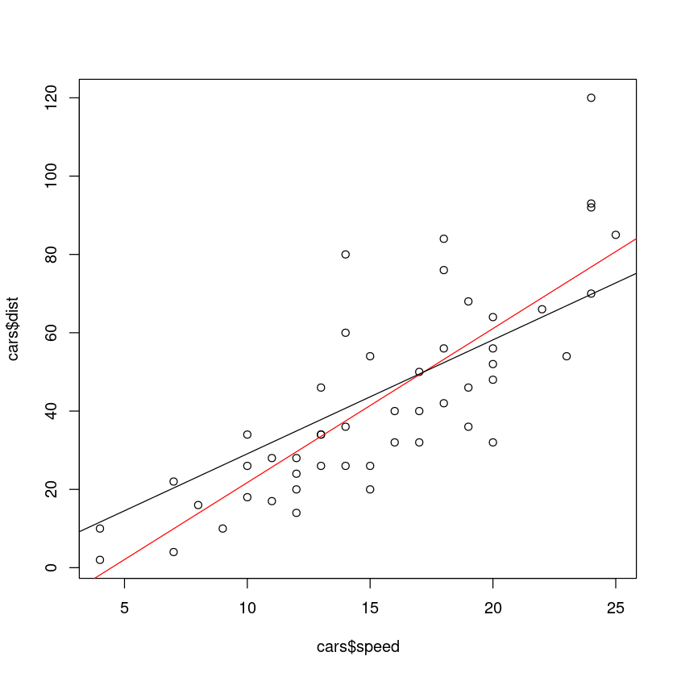

```r
#Plot the data
#A scatter plot
plot(cars$speed, cars$dist)

#plot the regression line
abline(fit,col="red")
abline(fit2)
```

# Residulas

Residuals refer to the differences between the observed values of the dependent variable and the values predicted by the regression model. For the i-th observation : the vertical distance from the i-th observation to the regression line

$$ \hat {e}_i = y_i - \hat {y} $$

where $\hat {y}$ is the predicted value when $x$ is $x_i$.

Least squares method ( The straight line minimizes the total of all squared residuals. )
$$\min \sum_{i=1}^{n} \hat {e}^2_i = \min \sum_{i=1}^{n}(y_i-\hat{y}_i)^2$$

The solutions for the regression are:

$\hat {\beta}_1=\frac{\sum_{i=1}^{n}(x_i-\bar{x})(y_i-\bar{y})}{\sum_{i=1}^{n}(x_i-\bar{x})^2}$

$\hat {\beta}_0=\bar{y}-\beta_1\bar{x}$

Example: Based on the predictive model with the intercept, predict the stopping distance if the speed is 14.

$ \hat{dist} = -17.57 + 3.93 speed $

The predicted distance = -17.57 + 3.93 x 14 = 37.45

Example: Based on the predictive model without the intercept, predict the stopping distance if the speed is 14.

```r
#Find the predicted value and a confidence interval
#Create a dataframe for the predictor(s)
 ndat = data.frame(speed=14)
#To make a prediction when speed = 14
#fit is related to the model with intercept
 predict(fit, newdata=ndat)
```

**1:** 37.4746277372263

```r
#Example:  Based on the predictive model without the intercept, predict the stopping distance if the speed is 14.
#fit2 is the model without the intercept
 predict(fit2, newdata=ndat)

#To add a confidence interval result
#  interval='confidence', level= 0.95
#To predict the average stopping dist for all cars with the speed = ...
predict(fit, newdata=ndat, interval='confidence', level= 0.95 )

#To add a predition interval result
#interval='prediction', level= 0.95
#To predict the stopping distance of a car when the driving speed is given
predict(fit, newdata=ndat, interval='predict', level= 0.95 )
```

**1:** 40.7278500151194

A matrix: 1 × 3 of type dbl

|  | fit | lwr | upr |
| --- | --- | --- | --- |
| 1 | 37.47463 | 32.94778 | 42.00147 |

A matrix: 1 × 3 of type dbl

|  | fit | lwr | upr |
| --- | --- | --- | --- |
| 1 | 37.47463 | 6.222305 | 68.72695 |

Exercise: please us the diamond data in canvas. Build a simple linear regression model to predict price based on carat. Report the model, and plot the model with data. Find the correlation and $R^2$.

```r
loc = "diamonda.csv"
 dat = read.csv(loc, header = 1)
 head(dat)
```

A data.frame: 6 × 10

|  | carat <dbl> | cut <chr> | color <chr> | clarity <chr> | depth <dbl> | table <dbl> | price <int> | x <dbl> | y <dbl> | z <dbl> |
| --- | --- | --- | --- | --- | --- | --- | --- | --- | --- | --- |
| 1 | 0.73 | Ideal | I | VS1 | 60.7 | 56 | 2397 | 5.85 | 5.81 | 3.54 |
| 2 | 0.70 | Ideal | G | VS1 | 60.8 | 56 | 3300 | 5.73 | 5.80 | 3.51 |
| 3 | 0.31 | Ideal | D | VS1 | 61.6 | 55 | 713 | 4.30 | 4.33 | 2.66 |
| 4 | 0.31 | Ideal | H | VVS1 | 62.2 | 56 | 707 | 4.34 | 4.37 | 2.71 |
| 5 | 0.31 | Ideal | E | IF | 60.9 | 55 | 987 | 4.39 | 4.41 | 2.68 |
| 6 | 0.83 | Good | E | SI1 | 63.7 | 59 | 3250 | 5.95 | 5.89 | 3.77 |

```r
fit = lm( price ~ carat, data = dat)
 summary(fit)
```

```
Call:
lm(formula = price ~ carat, data = dat)

Residuals:
    Min      1Q  Median      3Q     Max
-5779.9  -870.3     4.2   623.1  7717.7

Coefficients:
            Estimate Std. Error t value Pr(>|t|)
(Intercept)  -2364.0      139.9  -16.89   <2e-16 ***
carat         7866.2      151.5   51.93   <2e-16 ***
---
Signif. codes:  0 ‘***’ 0.001 ‘**’ 0.01 ‘*’ 0.05 ‘.’ 0.1 ‘ ’ 1

Residual standard error: 1569 on 498 degrees of freedom
Multiple R-squared:  0.8441,	Adjusted R-squared:  0.8438
F-statistic:  2696 on 1 and 498 DF,  p-value: < 2.2e-16
```

0.918751207698635

[figure not shown]

```r
#Plot the data
#A scatter plot
plot(dat$carat, dat$price, xlab ="Carat",  ylab ="Price")
#plot the regression line
abline(fit,col="red")


cor(dat$carat, dat$price)
```

Excercise: MASS , data(cat) #The cat dataset contains measurements on 97 domestic cats, separated by sex. It was introduced in the context of analyzing body and organ weights.

1. **Fit a regression model**  
   Fit a simple linear regression model of **heart weight (`Hwt`)** on **body weight (`Bwt`)**:
   - Report the estimated regression equation.
   - Interpret the slope ((\beta_1)) in context.
2. **Prediction**  
   Using the fitted model, predict the heart weight of a cat with a body weight of **3.0 kg**.
3. **Residual Analysis**
   - Plot the residuals of the regression model.
   - Do they show any clear patterns (e.g., curvature, unequal spread)?
   - What does this tell you about the assumptions of linear regression?
4. **Model Fit**
   - Compute the coefficient of determination ((R^2)).
   - Explain what this value means in the context of the data.

# Residual plots

It can be helpful to check if the model has a good fit or not. In a residual plot, we plot the predictor against the residuals; or we plot the predicted values against residuals.

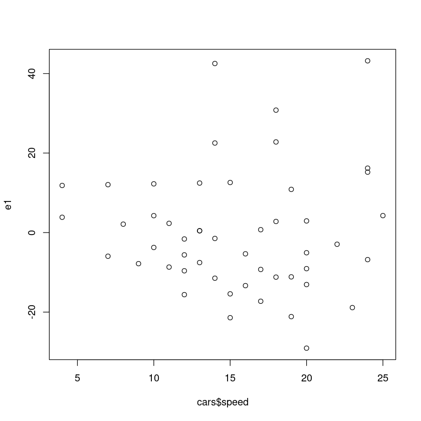

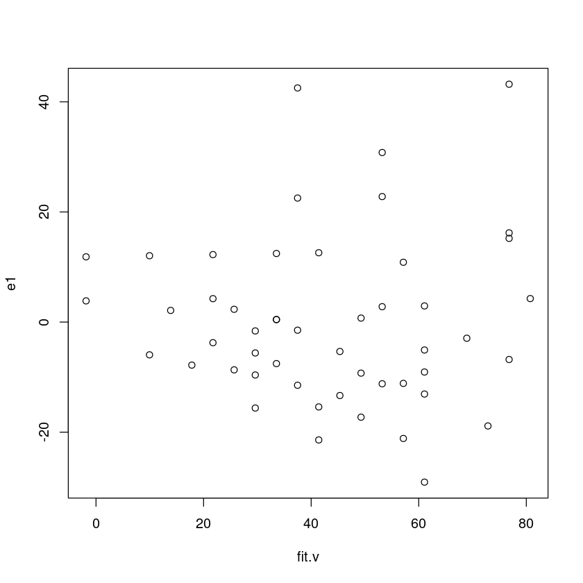

```r
#Residual plot
#to obtain the residuals of the model with the intercept
e1 = fit$residuals
#fitted values of the model
fit.v = fit$fitted

#cars$speed :
plot(cars$speed, e1)

#fit.v : predicted values
#e1: residuals
plot(fit.v, e1)

#If there are any curved patterns, ... , maybe we can improve the model.
#If the residuals are around zero or not at different values of predictor or predicted values
```

# Correlation

The Pearson correlation coefficient measures the strength and direction of the relationship between two quantitative variables. The sample correlation is

$$r=\dfrac{\sum_{i=1}^{n}(x_i-\bar{x})(y_i-\bar{y})}{\sqrt{\sum_{i=1}^{n}(x_i-\bar{x})^2\sum_{i=1}^{n}(y_i-\bar{y})^2}}$$

Comments:

$r$ is always between –1 and 1. The extreme value r = -1 or r = 1 occurs when the points in the scatterplot lie exactly along a straight line.

Correlation r measures only the linear relationship between two variables. Correlation does not describe curved relationships between variables, no matter how strong they are.

If there is a strong positive linear relationship between the variables, the correlation r is close to +1. If there is a strong negative linear relationship between the variables, the correlation r is close to -1. When two variables have weak or no association, the correlation r is close to 0.

a positive linear relationship : r > 0

a negative linear relationship : r < 0

The absolute value of $r$ tells the strength of a relationship and the sign indicate the direction.

The coefficient of determination: $r^2$

The percentage of the varition in the response can be explained by the model. If $r^2 = 100\%$, the model is perfect to predict the response given the predictor.

```r
#The calculation of the correlation:
#the correlation between speed and dist
r = cor(cars$speed, cars$dist)
r

#The r squared
r^2
#About 65% inforamtion in dist can be predicted by the speed.
```

0.80689490068921

0.651079380758251

Table: Comparison of Simple Linear Regression and Correlation

| **Aspect** | **Simple Linear Regression** | **Correlation** |
| --- | --- | --- |
| **Primary Goal** | Model the relationship between one independent variable (predictor) and one dependent variable (target) to make predictions. | Measure the strength and direction of the linear relationship between two variables. |
| **Key Output** | Coefficients $\beta_0$ (intercept) and $\beta_1$ (slope) for prediction. | Correlation coefficient $r$ (often Pearson’s $r$), ranging from $-1$ to $+1$. |
| **Direction of Relationship** | Asymmetrical: defines a dependent variable (Y) and an independent variable (X); swapping them changes the model. | Symmetrical: correlation between X and Y is the same as between Y and X. |
| **Statistical Basis** | Fits a "best-fit" line by minimizing squared vertical distances (errors) between data points and the line. | Quantifies how closely two variables vary together; does not fit a line to the data. |
| **Role in Machine Learning** | A supervised learning algorithm used for predictive modeling. | A statistical tool for feature selection and exploratory data analysis. |

# 3.2 Performance measure for a predictive model

## Regression:

1. Mean Absolute Error (MAE): The average of the absolute differences between predicted and actual values. The average of the absolute residuals.

$$MAE=\frac{1}{n}\sum_{i=1}^{n} |y_i-\hat{y}_i|$$

2. Mean Squared Error (MSE): The average of the squared differences between predicted and actual values.

$$MSE=\frac{1}{n}\sum_{i=1}^{n}(y_i-\hat{y}_i)^2$$

3. Root Mean Squared Error (RMSE): The square root of the MSE. It's in the same units as the response and provides a more interpretable measure of error.

$$RMSE = \sqrt {MSE} = \sqrt { \frac{1}{n}\sum_{i=1}^{n}(y_i-\hat{y}_i)^2 } $$

4. R-squared ($R^2$) : A measure of how well the model explains the variance in the response. It ranges from 0 to 1, with a higher value indicating a better fit.

R-squared = $r^2$  
where $r$ is the correlation between the predicted values and the true observed values.

It's beneficial to compute both the Mean Square Error and the R-squared, as each metric provides distinct insights. MSE reveals the average deviation between the predicted values generated by the model and the actual values. Conversely, $R^2$ informs us about the effectiveness of the predictor variables in accounting for the variability in the response variable.

For example: if R-squared is 0.83, about $83\%$ of the information (varition) in the response can be predicted (interpreted) by the model.

5. Median Absolute deviation (MAD): The median of the absolute differences between predicted and actual values.

   The median of all $ |y_i-\hat{y}_i | $, $i = 1, 2, \cdots, n$.

## Classification:

The primary objective is to predict a target variable that takes on discrete values (classes or categories). To assess the performance, these metrics include:

1. **Classification Accuracy**:  
   This is the proportion of correctly predicted instances out of the total instances. It is the simplest and most intuitive metric, but it can be misleading, especially when dealing with imbalanced datasets.

$$ \text{Accuracy} = \frac{\text{Number of Correct Predictions}}{\text{Total Number of Predictions}} $$

2. **Logarithmic Loss (Log Loss)**:  
   Log loss measures the uncertainty of predictions by penalizing confident and incorrect classifications more heavily. It provides a measure of how close the predicted probabilities are to the actual class labels, where lower values indicate better performance.

$$ where (y_i) is the actual class label and (p_i) is the predicted probability for that class.

3. **Area Under the Curve (AUC)**:  
   The Area Under the Receiver Operating Characteristic (ROC) Curve (AUC-ROC) measures the model’s ability to distinguish between the classes. A higher AUC indicates a better performance, with 1 being perfect classification and 0.5 indicating random guessing.
4. **F1 Score**:  
   The F1 score is the harmonic mean of precision and recall. It is useful when you need to balance the trade-off between precision (positive predictive value) and recall (sensitivity), especially in cases of class imbalance.

$$ F1 = 2 \times \frac{\text{Precision} \times \text{Recall}}{\text{Precision} + \text{Recall}} $$

5. **Precision**:  
   Precision measures how many of the predicted positive instances are actually positive. It is a useful metric when the cost of false positives is high.

$$ \text{Precision} = \frac{\text{True Positives}}{\text{True Positives} + \text{False Positives}} $$

6. **Recall (Sensitivity or True Positive Rate)**:  
   Recall measures how many actual positive instances the model is able to identify. It is important when the cost of false negatives is high.

$$ \text{Recall} = \frac{\text{True Positives}}{\text{True Positives} + \text{False Negatives}} $$

7. **Confusion Matrix**:  
   A confusion matrix provides a detailed breakdown of the model’s predictions by showing the counts of true positive (TP), true negative (TN), false positive (FP), and false negative (FN) predictions. It serves as the foundation for other metrics and provides a comprehensive view of the classification performance.

Example: find MSE, RMSE, MAE, and MAD for the predictive model using speed to predict stopping distance in the R cars data.

```r
#str(fit)
# the difference between the actual values and the predicted values
#fit$residuals
rd0 = cars$dist - fit$fitted.values

#MSE
MSE =mean( rd0^2)
MSE

#RMSE
sqrt(MSE)

#MAD
median( abs(rd0))

#MAE
mean(abs(rd0))

#R-squared
r = cor(cars$dist, fit$fitted.values )
RSQ = r^2
RSQ

#About 65% information in the response is explained by the model.
```

227.070421021898

15.0688559957914

10.2365693430657

11.5801191240876

0.651079380758251

```r
Exercise: find MSE, RMSE, MAE, and MAD for the predictive model using carat to predict price in the diamond data.
```

# 3.3 Variants of a simple linear regression

## Polynomial regression

Polynomial regression is a type of regression in machine learning for modeling the relationship between a the response and one or more predictors by fitting a polynomial equation to the data. Unlike simple linear regression, polynomial regression can capture more complex and non-linear relationships between variables.

$$Y_i = \beta_0 + \beta_1 X_i + \beta_2 X_i^2 + \ldots + \beta_k X_i^k + \varepsilon_i$$

R codes: fit = lm(y ~ poly(x , k , raw=T), data= …)

A data.frame: 6 × 2

|  | age <dbl> | bone <dbl> |
| --- | --- | --- |
| 1 | 0.000000 | 0.00000 |
| 2 | 5.112000 | 20.22000 |
| 3 | 1.320000 | 11.11130 |
| 4 | 35.240000 | 140.65000 |
| 5 | 1.632931 | 26.15218 |
| 6 | 2.297635 | 10.00100 |

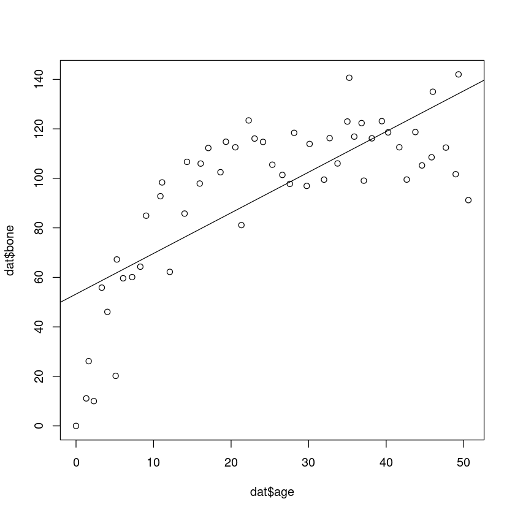

```r
# In the previous Example, a simple linear model may be good.
# Run a simple linear regression using the jaws.txt
# Make a scatter plot

lc = "~/data/jaws.txt"
dat = read.table(lc, header = 1)
head(dat)

#To predict bone by age
#A scatter plot
plot(dat$age, dat$bone)

fit = lm(bone~age, data = dat)
abline(fit)
```

```
Call:
lm(formula = bone ~ poly(age, 4, raw = T), data = dat)

Residuals:
    Min      1Q  Median      3Q     Max
-31.113  -8.709   2.113   7.864  30.821

Coefficients:
                         Estimate Std. Error t value Pr(>|t|)
(Intercept)            -2.1420376  7.9523900  -0.269  0.78879
poly(age, 4, raw = T)1 13.2615955  2.3143042   5.730 6.08e-07 ***
poly(age, 4, raw = T)2 -0.6113393  0.1898792  -3.220  0.00228 **
poly(age, 4, raw = T)3  0.0129267  0.0056683   2.281  0.02696 *
poly(age, 4, raw = T)4 -0.0001022  0.0000555  -1.841  0.07173 .
---
Signif. codes:  0 ‘***’ 0.001 ‘**’ 0.01 ‘*’ 0.05 ‘.’ 0.1 ‘ ’ 1

Residual standard error: 13.33 on 49 degrees of freedom
Multiple R-squared:  0.8524,	Adjusted R-squared:  0.8403
F-statistic: 70.72 on 4 and 49 DF,  p-value: < 2.2e-16
```

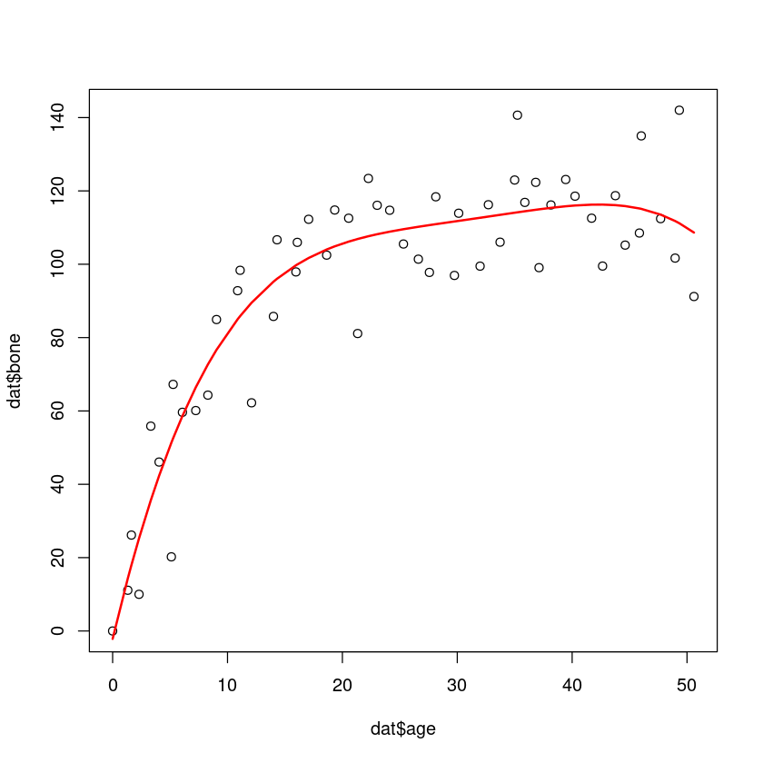

```r
#Use 4-th order ploynomial
fit.4 = lm(bone ~ poly(age , 4 , raw=T), data= dat)
summary(fit.4)

#The model equation:
# \hat {bone}  = -2.14 + 13.261 age - 0.6113  age^2 + 0.0129 age^3 - 0.00010 age^4

#Plot the data and the model
#Find the predicted values for different ages
pred = predict(fit.4, newdata = data.frame(age = sort(dat$age)))
#A scatter plot
plot(dat$age, dat$bone)
lines(sort(dat$age), pred, col='red', lwd=2)
```

```r
#Model performance metric for both the simple linear regression and the polynomial regression
#MAE,  RMSE,  R^2

#For the simple linear regression
#The redisudals (errors) of fit which is for the simple linear regression
e1 = fit$residuals

#The redisudals (errors) of fit.4 which is for the polynomial linear regression
e4 = fit.4$residuals

MAE.1 = mean(abs(e1))

MAE.4 = mean(abs(e4))

MAE.1
MAE.4

#MAE.4 is smaller ==> polynomial regression impove the model


RMSE.1 = sqrt(mean((e1)^2) )

RMSE.4 =  sqrt(mean((e4)^2) )

RMSE.1
RMSE.4

#R^2
#The fitted values (the predicted values)
y1.fitted = fit$fitted.values
y4.fitted = fit.4$fitted.values

#R^2 for the simple linear regression
R2.1 = (cor(dat$bone, y1.fitted ))^2

#R^2 for the polynomial regression
R2.4 = (cor(dat$bone, y4.fitted ))^2

print("R^2 for the simple linear regression")
R2.1

print("R^2 for the polynomail regression with order = 4")

R2.4
#R2.4 is bigger than R2.1: the ploynomial regression model is better.
```

17.3835020897923

10.1327642614788

21.8810609668068

12.7019281258497

```
[1] "R^2 for the simple linear regression"
```

0.561853131359612

```
[1] "R^2 for the polynomail regression with order = 4"
```

0.852353804154698

```r
fit = lm(bone~age, data =dat)    # with(dat, lm(bone~age))
#Plot the data
plot(dat$age, dat$bone)
#plot the regression line
abline(fit,col="red")

MSE.fit =mean( fit$residuals ^2)
 print(MSE.fit)

r = cor(dat$bone, fit$fitted.values )
RSQ = r^2
print(RSQ)

#Polynomial regression  ,   polynomial feature
#polynomial with the order of 3
 k = 3
 fit.1 = lm(bone ~ poly(age , k , raw = T), data= dat)

 #Find the MSE of the model
 MSE.fit1 =mean( fit.1$residuals ^2)
 print(MSE.fit1)

r = cor(dat$bone, fit.1$fitted.values )
RSQ.1 = r^2
print(RSQ.1)

#MSE, the smaller the better;  R^2 : the higher the better

pred = predict(fit.1, newdata = data.frame(age = sort(dat$age)))
lines(sort(dat$age), pred, col='red', lwd=2)
```

[output not shown]

Excersie: use the "nonlinear.csv" in canvas. Please run a simple linear regression and a polynomoal regression with order =3 to use x to predict y.

a. Plot the data and the models. b. Compare their performance using MAE, RMSE, $R^2$.

# Variants of a simple linear regression

## Median Regression

Median regression, also known as **0.5 quantile regression**, is a robust alternative to ordinary least squares (OLS) regression. Instead of modeling the **conditional mean**, it models the **conditional median** of the response variable, making it **less sensitive to outliers**.

**Objective Function**
Median regression minimizes the sum of absolute residuals (the $L_1$ loss): $$ MAD = \sum_{i=1}^{n} \lvert y_i - \hat{y}_i \rvert $$

Unlike OLS, which minimizes squared errors and is heavily influenced by outliers, median regression focuses on absolute deviations, providing robustness against extreme values. Estimated coefficients represent the change in the **median** of the response for a one-unit change in the predictor.

- **OLS**: minimizes squared residuals $\rightarrow$ estimates the conditional **mean**.
- **Median regression**: minimizes absolute residuals $\rightarrow$ estimates the conditional **median**.

Median regression is particularly useful when:

- The data contain outliers.
- The error distribution is skewed or heavy-tailed.
- The median relationship is of primary interest rather than the mean.

Use a modified version of the classic cars dataset (dat1[1,2] = 186). Perform a median regression with speed as the predictor variable and dist (stopping distance) as the response variable.

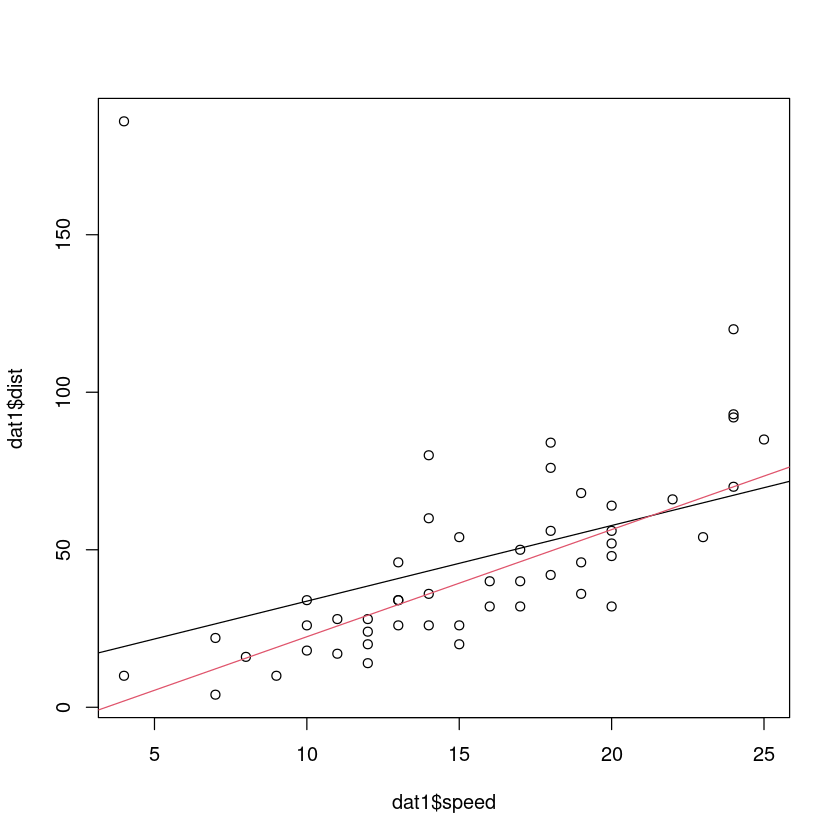

```r
library(quantreg)
dat1 = cars
dat1[1,2] = 186

plot(dat1$speed, dat1$dist)

#Median regression
fit = lm(dist~speed, data = dat1)
fit.1 = rq(dist~speed, data = dat1)

abline(fit)

abline(fit.1, col=2)
```

# Overfitting

Overfitting is a common issue in predictive modeling. It occurs when a model learns the training data too closely, capturing random noise or fluctuations rather than just the underlying patterns or relationships. As a result, an overfit model performs very well on the training data but fails to generalize effectively to unseen data.

Key characteristics of overfitting include unusually high training accuracy, poor generalization to new datasets, and excessive model complexity. An overfit model often exhibits high variance in its predictions and may capture irrelevant or spurious patterns that have no true predictive value.

To prevent or address overfitting, it is often helpful to start with a simpler model. Techniques such as cross-validation can be used to evaluate model performance more reliably, while regularization methods (such as Ridge, Lasso, or Elastic Net) help reduce unnecessary complexity. Model selection plays a crucial role in balancing bias and variance, and feature selection ensures that only the most relevant variables are included. In addition, strategies like early stopping or increasing the size and diversity of the training data can further improve generalization.

# Data Splitting: Training and Test Datasets

One major challenge in predictive modeling is ensuring that a model performs accurately on new data. Training and test datasets are essential concepts in predictive modeling and machine learning, and they play a crucial role in both developing and evaluating predictive models. To properly assess performance, it is important to test a model on data points that were not included in the training process. These unseen data points act as a measure of the model’s ability to generalize beyond the data it was built on.

Among the most reliable methods for assessing model effectiveness is **cross-validation**. This technique involves setting aside a portion of the dataset for testing, separate from the training data. After building the model on the training set, the reserved portion is used to evaluate its performance. The model generates predictions for the test data, and these predictions are compared against the actual values to measure accuracy.

The **training data** is the subset of the dataset used to fit the model and learn the underlying patterns. In contrast, the **test data** is kept separate and never seen by the model during training. Its purpose is to serve as an independent benchmark for evaluating how well the model generalizes to new, unseen data. After training is complete, the test set provides a realistic assessment of predictive performance.

The proportion of training and test data can vary depending on the dataset and the problem, but a common practice is to allocate 70–80% of the data for training and 20–30% for testing. In many cases, multiple models are trained and evaluated using the same test set to identify the one with the best performance. Properly separating data into training and test sets ensures that performance estimates are both realistic and unbiased, better reflecting how the model will behave in real-world applications.

# Cross-Validation

Cross-validation is a fundamental technique used to ensure that predictive models are robust and capable of generalizing to new, unseen data. It works by repeatedly resampling the dataset, fitting the model on different subsets, and then testing it on the remaining data. This process provides a reliable estimate of model performance in practice and helps detect overfitting. When a model performs significantly better on the training data than on the validation data, it often indicates that the model is overfitting.

Several cross-validation methods are commonly used:

### 1. Leave-One-Out Cross-Validation (LOOCV)

In this method, the model is trained on all but one data point and tested on the single point that was left out. This process is repeated until each data point has served once as the test set. LOOCV is especially useful for small datasets or when accuracy is critical. However, it is computationally expensive for large datasets because it requires fitting the model $n$ times, where $n$ is the total number of data points.

### 2. k-Fold Cross-Validation

This approach splits the data into $k$ equal parts (folds). The model is trained and tested $k$ times, with each fold serving once as the test set while the remaining $k-1$ folds are used for training. The results are then averaged to provide an overall performance measure. This method offers a good balance between accuracy and efficiency. Note that Leave-One-Out is a special case of $k$-Fold Cross-Validation where $k = n$.

*(For illustrations, see the plots in [scikit-learn’s documentation](https://scikit-learn.org/stable/modules/cross_validation.html).)*

### 3. Repeated k-Fold Cross-Validation

Repeated k-Fold extends the basic k-Fold method by performing the process multiple times ($p$ repetitions) with different random splits of the data in each iteration. Each repetition divides the dataset into $k$ folds, trains and evaluates the model, and then averages the results. Repeating the procedure adds robustness by reducing the variance of the performance estimate, since the model is tested on multiple random partitions of the dataset.

### 4. Leave-P-Out Cross-Validation (LPO)

Leave-P-Out is a generalization of LOOCV. Instead of leaving out one sample at a time, exactly $p$ samples are left out in each iteration, and the model is trained on the remaining $n-p$ data points. The process is repeated for all possible combinations of $p$ left-out samples. While this method is very thorough, it quickly becomes computationally impractical as $p$ grows.

...

```r
#Split the data into a training set and a testing set

#setting seed to generate a
#reproducible random sampling
set.seed(1251)


#creating training data as 85% of the dataset
library(caret)
data(cars, package='caret')
dat = cars
train.index  =  createDataPartition(dat$Mileage, p = 0.85, list = FALSE)

#generating training dataset
#from the random_sample
training.dat =  dat[train.index, ]

#generating testing dataset
#from rows which are not included in training set
testing.dat  =  dat[-train.index, ]

#str(dat)
#str(training.dat)

#Fit a model using the training data
fit.train = lm(Price~Mileage, data = training.dat)

#Predict the price using the test data
pre.price = predict(fit.train, newdata = testing.dat)

#prediction errors in the testing data
err = testing.dat$Price - pre.price

#Predicton MSE
MSE = mean( err^2)

print(MSE)

#R squared
r = cor(pre.price, testing.dat$Price)

RSQUARE = r^2
print (RSQUARE)

#According to R^2 = .014 , the predictive model seems "not good".
```

```
[1] 111198796
[1] 0.01453313
```

```r
#Fit a model using the training data using three variables  (Mileage + Cylinder   +  Doors)
fit.train = lm(Price~Mileage + Cylinder +  Doors       , data = training.dat)

#Predict the price using the test data
pre.price = predict(fit.train, newdata = testing.dat)

#prediction errors in the testing data
err = testing.dat$Price - pre.price

#Predicton MSE
MSE = mean( err^2)

print(MSE)

#R squared
r = cor(pre.price, testing.dat$Price)

RSQUARE = r^2
print (RSQUARE)

#According to R^2 = .44 , the predictive model seems improved ....
```

[output not shown]

```r
dat = cars
```

```r
#Leave-One-Out Cross-Validation (LOOCV)

#set.seed(1241)
cv.control = trainControl(method = "LOOCV")

#Linear regression
fit = train( dist ~ speed, data = dat, method ="lm", trControl = cv.control)
fit$finalModel
summary(fit)

#Fit on the whole data. no difference for 'lm'
fit2 = lm(dist ~ speed, data = dat)
fit2
```

```
Call:
lm(formula = .outcome ~ ., data = dat)

Coefficients:
(Intercept)        speed
    -17.579        3.932
```

```
Call:
lm(formula = .outcome ~ ., data = dat)

Residuals:
    Min      1Q  Median      3Q     Max
-29.069  -9.525  -2.272   9.215  43.201

Coefficients:
            Estimate Std. Error t value Pr(>|t|)
(Intercept) -17.5791     6.7584  -2.601   0.0123 *
speed         3.9324     0.4155   9.464 1.49e-12 ***
---
Signif. codes:  0 ‘***’ 0.001 ‘**’ 0.01 ‘*’ 0.05 ‘.’ 0.1 ‘ ’ 1

Residual standard error: 15.38 on 48 degrees of freedom
Multiple R-squared:  0.6511,	Adjusted R-squared:  0.6438
F-statistic: 89.57 on 1 and 48 DF,  p-value: 1.49e-12
```

```
Call:
lm(formula = dist ~ speed, data = dat)

Coefficients:
(Intercept)        speed
    -17.579        3.932
```

```r
# k-Fold Cross-Validation, k = 8
cv.control =  trainControl(method = "cv", number = 8)

#Linear regression
fit.cv = train(dist ~ speed, data = dat, method ="lm", trControl = cv.control)
fit.cv

# Repeated K-Fold Cross-Validation, k = 10,  repeats = 10
set.seed(32421)
cv.control =  trainControl(## 10-fold CV
                           method = "repeatedcv",
                           number = 10,
                           ## repeated ten times
                           repeats = 10)

#Linear regression
fit.rcv = train(dist ~ speed, data = dat, method ="lm", trControl = cv.control)
#summary(fit.rcv)
fit.rcv

#The resampling method: "boot", "boot632", "optimism_boot", "boot_all",
#"cv", "repeatedcv", "LOOCV", "LGOCV" (for repeated training/test splits),
#"none" (only fits one model to the entire training set),
#"oob" (only for random forest, bagged trees, bagged earth, bagged flexible discriminant analysis, or conditional tree forest models),
#timeslice, "adaptive_cv", "adaptive_boot" or "adaptive_LGOCV"
```

```
Linear Regression

50 samples
 1 predictor

No pre-processing
Resampling: Cross-Validated (8 fold)
Summary of sample sizes: 44, 44, 42, 44, 44, 45, ...
Resampling results:

  RMSE      Rsquared   MAE
  14.58215  0.7329931  11.74559

Tuning parameter 'intercept' was held constant at a value of TRUE
```

```
Linear Regression

50 samples
 1 predictor

No pre-processing
Resampling: Cross-Validated (10 fold, repeated 10 times)
Summary of sample sizes: 45, 44, 44, 45, 46, 44, ...
Resampling results:

  RMSE      Rsquared   MAE
  14.45077  0.7043576  11.88348

Tuning parameter 'intercept' was held constant at a value of TRUE
```